# TP5 - Econometrics

# Part 1 : Warm up - Data settings and unit root tests :

## Exercise 1 : Data settings.

### ata importation can be automated using R features and packages. There exists several API facilitating economic and financial import and update. Load the Advance Retail Sales - namely the Retail Trade from the Federal Reserve of Saint Louis 1 ?

```r
data <- read.csv("us retail sales.csv", header = TRUE, sep = ";")
head(data)
```

```
##   observation_date RSXFSN
## 1       1992-01-01 130683
## 2       1992-02-01 131244
## 3       1992-03-01 142488
## 4       1992-04-01 147175
## 5       1992-05-01 152420
## 6       1992-06-01 151849
```

### Check the status of the imported data and transform it into a right object if necessary. Plot thedata. What do you observe ? What type of seasonal pattern is ? What type of the filters do you propose to clean the retail sales.

```r
data$observation_date <- as.Date(data$observation_date, format = "%Y-%m-%d")
head(data)
```

```
##   observation_date RSXFSN
## 1       1992-01-01 130683
## 2       1992-02-01 131244
## 3       1992-03-01 142488
## 4       1992-04-01 147175
## 5       1992-05-01 152420
## 6       1992-06-01 151849
```

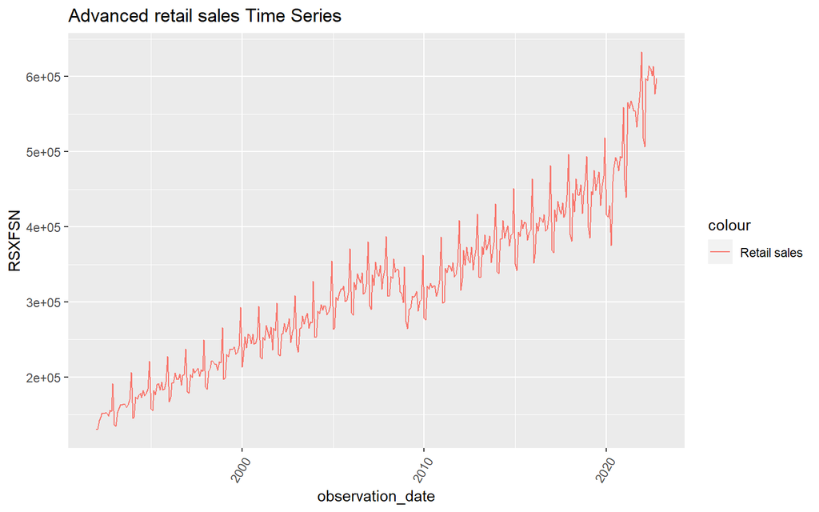

```r
library(ggplot2)
RSXFSN = ts(data$RSXFSN, start = c(1992,1), frequency = 12)
p1 <- ggplot(data, aes(x = observation_date, y = RSXFSN, col= "Retail sales")) + geom_line()+
  theme(axis.text.x=element_text(angle=60, hjust=1)) +
  scale_x_date(limit=c(as.Date("1992-01-01"),as.Date("2022-10-01")))+
  ggtitle("Advanced retail sales Time Series")
p1
```

On observe que le processus correspond à un processus à schema additif à tendance croissante avec des pics de saisonnalité. La série temporelle n’étant pas stationnaire, on peut se proposer d’appliquer un filtre linéaire et un filtre en différence première pour identifier le type de non stationnarité.

Pour l’instant, on se concentre sur la saisonnalité. On va appliquer une fonction de décomposition pour retirer l’information inutile car réccurente.

### 3. Run the required filter to cut the seasonal pattern ? You can choose between the seasonal regression, the moving average filter and the decompose function (this function is based on moving average seasonal filters as well).

On va tout d’abord retirer la saisonnalité :

```r
library(stats)
library(forecast)
```

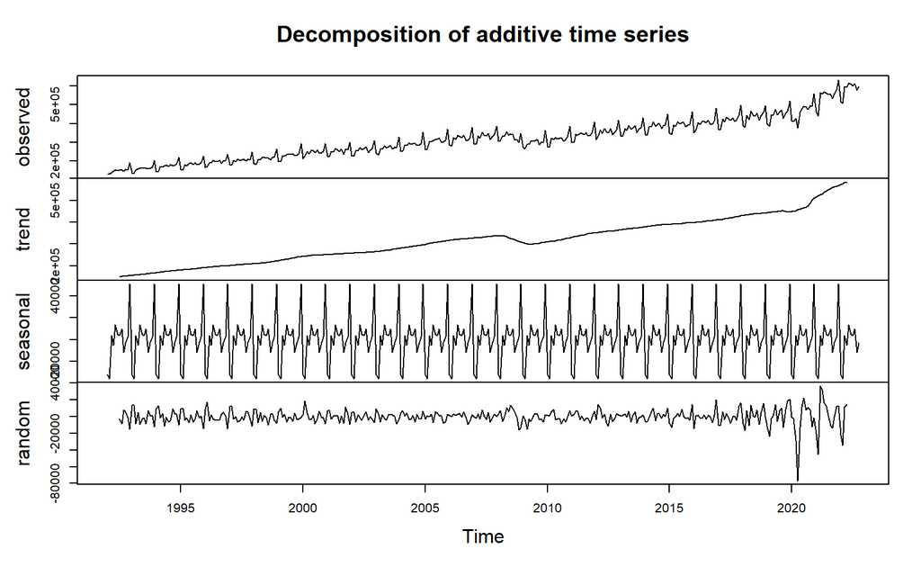

```r
decompose <- decompose(RSXFSN, "additive")
plot(decompose)
```

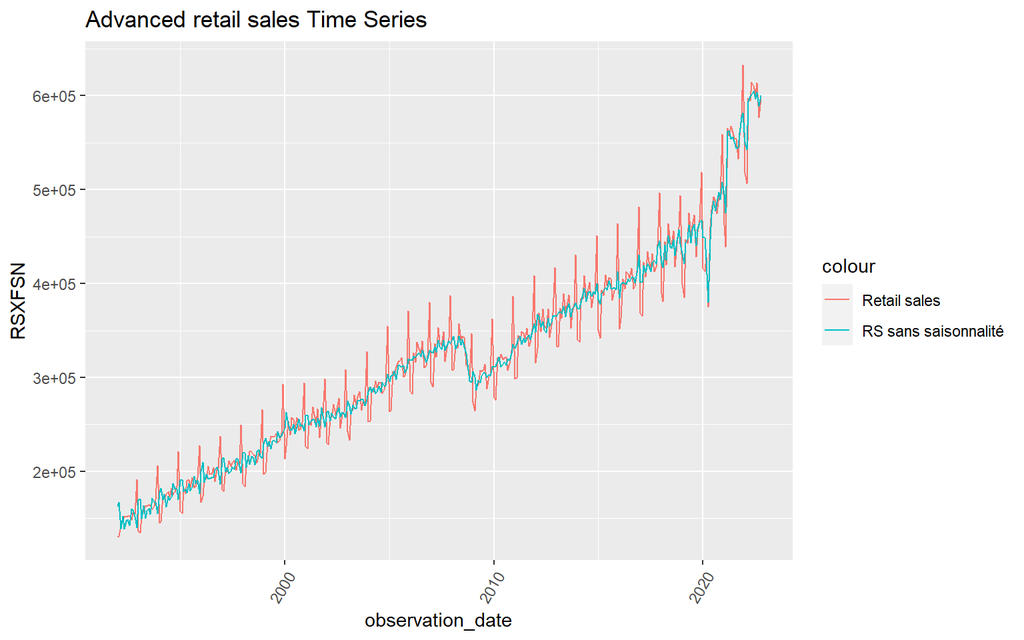

```r
deseason <- seasadj(decompose)
p2 <- p1 + geom_line(aes(y = deseason, col = "RS sans saisonnalité"))
p2
```

On observe avec les outils utilisés la décomposition de la série temporelle. On retire la saisonnalité et on observe le plot final.

### 4. Grab the filtered data and check using the right tool the seasonal pattern has been deleted. Is this filtered data be modeled using an ARMA(p,q) approach ?

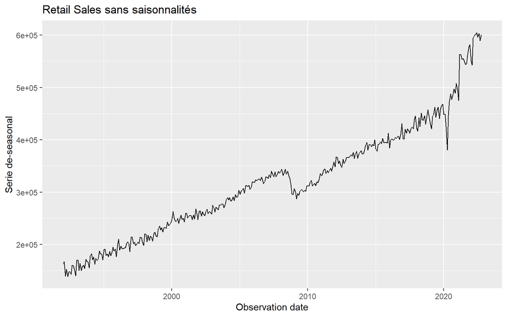

```r
library(forecast)

ts.stl <- stl(RSXFSN,"periodic")  # On decompose la série temporelle
ts.sa <- seasadj(ts.stl)  # On retire les saisonnalités

p3 <- ggplot(data, aes(x = data$observation_date)) + geom_line(aes(y = ts.sa)) + xlab("Observation date") + ylab("Serie de-seasonal") + ggtitle("Retail Sales sans saisonnalités")
p3
```

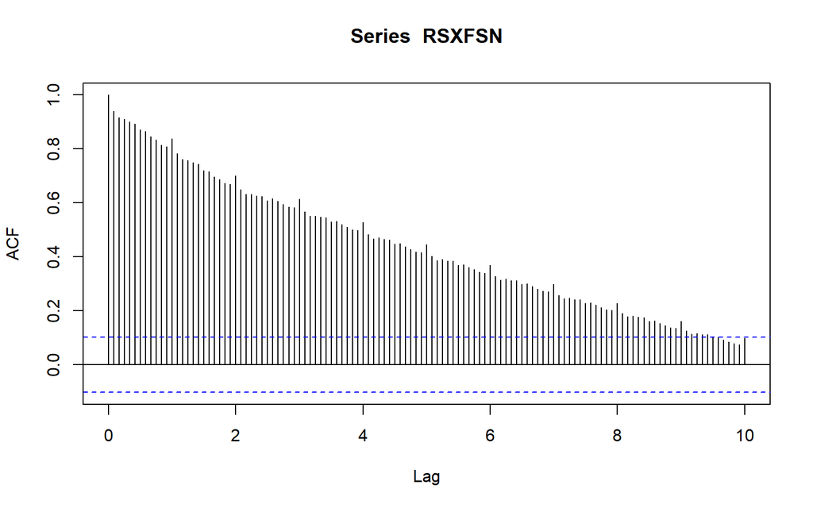

```r
acf(RSXFSN, lag = 120)
```

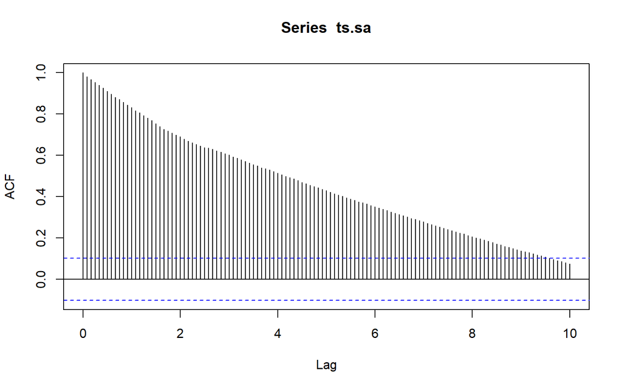

```r
acf(ts.sa, lag =120)
```

En observant la représentation graphique du modèle généré, on constate que l’on a bien enlevé les saisonnalités. De plus, ce resultat est confirmé par l’ACF, on voit que la serie modifiée ne présente plus de pics récurents.

La présente de forte autocorrélation et l’abscence de stationnarité nous indiquent de plus que la serie de peut actuellement pas être approchée par un modèle ARMA.

## Exercise 2 : Unit Root tests

Dans cette exercice on revient sur le commentaire effectué précedemment, l’abscence actuelle de stationnarité de la série temporelle même une fois ajustée est due à la présence d’une tendance croissante. On se propose d’identifier le type de non stationnarité (TS ou DS).

### 1. Load the “urca” package. Summarize quickly the step-wise approach of the Dickey Fuller test.Compute the Augmented Dickey Fuller test using the right function on the filtered data (note that the selection of the number of lags can be performed on a discretionary way or automatically).

On effectue le test de dickey fuller augmenté.

```r
library(urca)
library(tseries)
df_test <- adf.test(ts.sa)
df_test
```

```
##
##  Augmented Dickey-Fuller Test
##
## data:  ts.sa
## Dickey-Fuller = 0.71203, Lag order = 7, p-value = 0.99
## alternative hypothesis: stationary
```

```r
adf_test <- ur.df(diff(ts.sa), type = "trend",7, selectlags = "AIC")
```

### 2. Determine then the integration degree of the data ?

```r
summary(adf_test)
```

```
##
## ###############################################
## # Augmented Dickey-Fuller Test Unit Root Test #
## ###############################################
##
## Test regression trend
##
##
## Call:
## lm(formula = z.diff ~ z.lag.1 + 1 + tt + z.diff.lag)
##
## Residuals:
##    Min     1Q Median     3Q    Max
## -56907  -5905    254   4742  72716
##
## Coefficients:
##               Estimate Std. Error t value Pr(>|t|)
## (Intercept)  6.730e+02  1.160e+03   0.580 0.562215
## z.lag.1     -2.212e+00  2.545e-01  -8.692  < 2e-16 ***
## tt           1.105e+01  5.544e+00   1.994 0.046965 *
## z.diff.lag1  8.282e-01  2.322e-01   3.567 0.000412 ***
## z.diff.lag2  3.917e-01  2.048e-01   1.912 0.056675 .
## z.diff.lag3  2.498e-01  1.688e-01   1.480 0.139782
## z.diff.lag4  4.717e-03  1.329e-01   0.035 0.971702
## z.diff.lag5  1.453e-03  9.079e-02   0.016 0.987236
## z.diff.lag6 -8.413e-02  5.271e-02  -1.596 0.111357
## ---
## Signif. codes:  0 '***' 0.001 '**' 0.01 '*' 0.05 '.' 0.1 ' ' 1
##
## Residual standard error: 10660 on 352 degrees of freedom
## Multiple R-squared:  0.6975, Adjusted R-squared:  0.6907
## F-statistic: 101.5 on 8 and 352 DF,  p-value: < 2.2e-16
##
##
## Value of test-statistic is: -8.6923 25.187 37.78
##
## Critical values for test statistics:
##       1pct  5pct 10pct
## tau3 -3.98 -3.42 -3.13
## phi2  6.15  4.71  4.05
## phi3  8.34  6.30  5.36
```

On determine dans un premier temps le nombre de lags à utiliser avec la fonction adf.test. Par la suite on applique le test adf avec le package urca sur la série différenciée. Cette derniere devant être stationnaire, on verifie ce résultat. On applique le test adf sur le type trend. On obtient de resultats nous permettant de conclure :

- la p-value est quasiment nulle, on peut donc affirmer avec quasi-certitude que comme p-value < 0.05 et même 0.01, on rejette l’hypothèse de non stationnarité de la série temporelle différenciée.
- Comme le coefficient de tt possède une t-value < 2.78. On conclut que la trend n’est plus significative pour la série différenciée.

En conclusion, on obtient que l’ordre d’intégration de la série est bien de
$$d = 1 \ (degré \
d'intégration)$$
. Car une seule application du filtre en différence première à suffit à stationnariser la série. On a donc bien retirer la trend et obtenu une série stationnaire.

https://www.youscribe.com/BookReader/Index/1445432/?documentId=1424183

### 3. Compute the Phillips and Perron test on the filtered data. Does it confirm your previous result ?

```r
pp_test <- ur.pp(ts.sa, model = "trend",use.lag = 7) # model: preciser ce qu'on a obtenu à la quesiton précédente
summary(pp_test)
```

```
##
## ##################################
## # Phillips-Perron Unit Root Test #
## ##################################
##
## Test regression with intercept and trend
##
##
## Call:
## lm(formula = y ~ y.l1 + trend)
##
## Residuals:
##    Min     1Q Median     3Q    Max
## -50579  -7086    108   5494  85698
##
## Coefficients:
##              Estimate Std. Error t value Pr(>|t|)
## (Intercept) 2.809e+04  7.473e+03   3.759 0.000198 ***
## y.l1        9.152e-01  2.346e-02  39.008  < 2e-16 ***
## trend       8.771e+01  2.346e+01   3.739 0.000214 ***
## ---
## Signif. codes:  0 '***' 0.001 '**' 0.01 '*' 0.05 '.' 0.1 ' ' 1
##
## Residual standard error: 11860 on 366 degrees of freedom
## Multiple R-squared:  0.9879, Adjusted R-squared:  0.9878
## F-statistic: 1.489e+04 on 2 and 366 DF,  p-value: < 2.2e-16
##
##
## Value of test-statistic, type: Z-alpha  is: -18.0325
##
##            aux. Z statistics
## Z-tau-mu              6.7046
## Z-tau-beta            2.7738
```

```r
pp_test@testreg$coefficients
```

```
##                 Estimate   Std. Error   t value      Pr(>|t|)
## (Intercept) 28093.082174 7.473334e+03  3.759110  1.984111e-04
## y.l1            0.915225 2.346221e-02 39.008472 1.947034e-132
## trend          87.714541 2.345658e+01  3.739443  2.139702e-04
```

Le test Phillips Perron confirme le resultat précedent.

### 4. Compute the KPSS test using one of the artificial data generated previously. Do we find the same conclusion ?

```r
kpss_test <- ur.kpss(ts.sa, lags = "long",use.lag = 7)
summary(kpss_test)
```

```
##
## #######################
## # KPSS Unit Root Test #
## #######################
##
## Test is of type: mu with 7 lags.
##
## Value of test-statistic is: 4.3959
##
## Critical value for a significance level of:
##                 10pct  5pct 2.5pct  1pct
## critical values 0.347 0.463  0.574 0.739
```

La statistique du test est encore une fois supérieure à la valeur critique à 1%. Le résultat est donc le même que précedemment. On rejette l’hypothèse de stationnarité de la TS.

### 4. Compute the KPSS test using one of the artificial data generated previously. Do we find the same conclusion ?

Pour determiner l’ordre d’intégration de la série temporelle, on applique le test Kpss à la série temporelle à laquelle on applique “d” filtres en différence première.

On essaye avec d = 1 :

```r
kpss_test <- ur.kpss(diff(ts.sa), lags = "long", use.lag = 7)
summary(kpss_test)
```

```
##
## #######################
## # KPSS Unit Root Test #
## #######################
##
## Test is of type: mu with 7 lags.
##
## Value of test-statistic is: 0.3392
##
## Critical value for a significance level of:
##                 10pct  5pct 2.5pct  1pct
## critical values 0.347 0.463  0.574 0.739
```

On observe alors que la statistique du test est inférieure à la valeur critique à 1%. On ne rejette donc pas l’hypothèse de stationnarité du test statistique. Il a donc suffit de d = 1 application du filtre en difference première pour obtenir une série stationnaire. On conclut alors que l’ordre d’intégration de la série temporelle est d = 1. On obtient alors la confirmation des resultats précédents.

## Exercise 3 : Modeling.

### 1. Given the results derived from the previous sections, propose the most relevant ARMA(p,q) framework to model the retail sales dynamics. Is there an alternative to the ARMA(p,d) approach ?

Pour pouvoir appliquer un modèle ARMA, il faut une série désaisonnalisée et stationnaire. On a déjà retirer les pics de saisonnalité dans la première partie. Dans la seconde partie, on a montrer à travers trois tests statistiques qu’il l’ordre d’intégration de la série temporelle Retail Sales est d = 1. De ce fait, on commence par appliquer un test en différence première pour obtenir une série stationnaire.

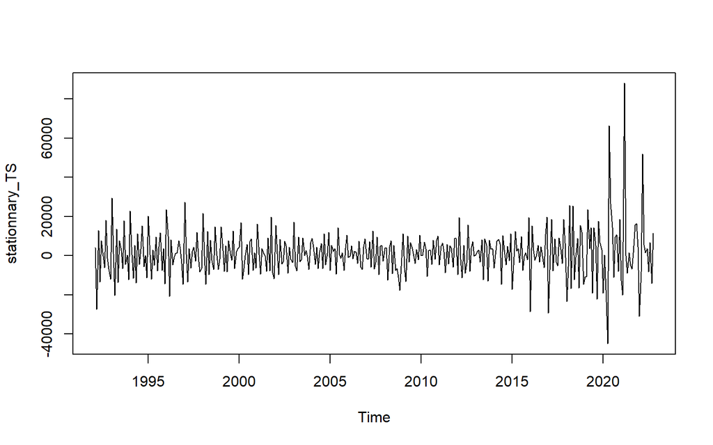

```r
library(ggplot2)
stationnary_TS <- diff(ts.sa)
plot(stationnary_TS)
```

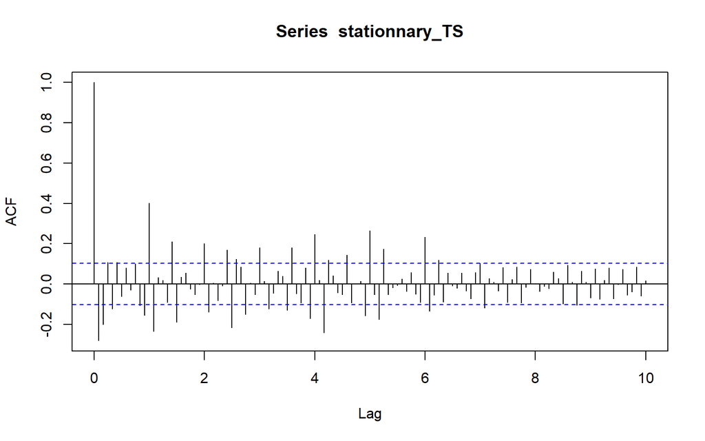

```r
acf(stationnary_TS, lag = 120)
```

On commence par représenter l’acf et la Pacf pour obtenir une approximation d’ordre MA et de l’ordre AR.

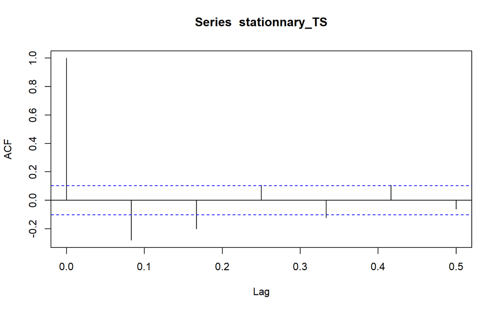

```r
acf(stationnary_TS, lag = 6)
```

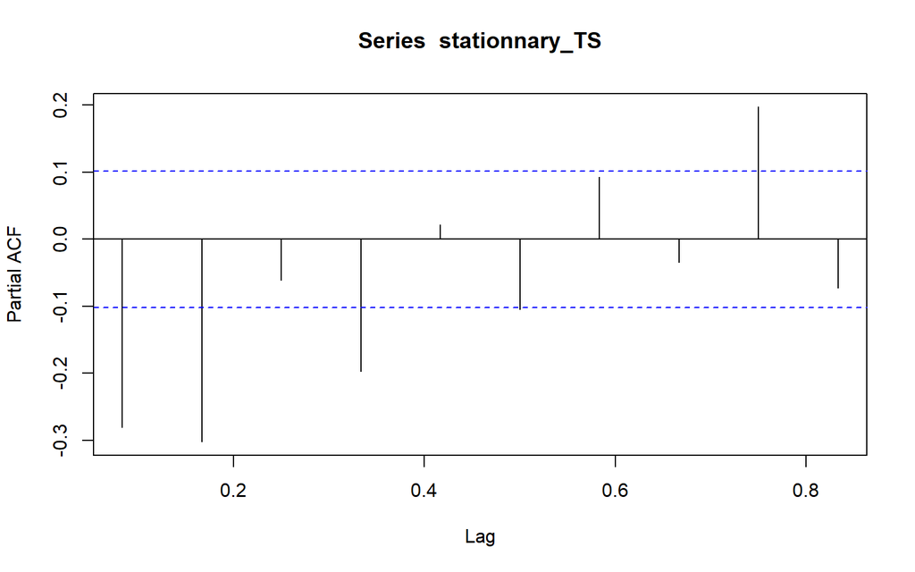

```r
pacf(stationnary_TS, lag = 10)
```

On observe dans un premier temps une premiere estimation : un modèle qui approche les données serait un ARMA(2,3) (on considère les pics qui dépassent significativement la limite statistique établie).

```r
AR_order <- seq(0,4)
MA_order <- seq(0,4)


likelihood = matrix(0,nrow = max(AR_order),ncol = max(MA_order))
AIC = matrix(0,nrow = max(AR_order),ncol = max(MA_order))
BIC = matrix(0,nrow = max(AR_order),ncol = max(MA_order))

for (p in AR_order) {
  for (q in MA_order) {
    model = arima(stationnary_TS, order = c(p,0,q))
    likelihood[p,q] = model$loglik # On recup la log vraissemblance
    AIC[p,q] = model$aic # On recupère l'AIC
    BIC[p,q] = BIC(model) # On recupère le BIC
  }
}
AIC
```

```
##          [,1]     [,2]     [,3]     [,4]
## [1,] 7921.518 7906.159 7908.005 7909.931
## [2,] 7918.097 7907.983 7905.485 7907.008
## [3,] 7919.425 7909.742 7906.640 7887.362
## [4,] 7907.014 7907.179 7906.452 7882.874
```

```r
#on observe une AIC minimale pour (4,4)
BIC
```

```
##          [,1]     [,2]     [,3]     [,4]
## [1,] 7937.161 7925.713 7931.469 7937.306
## [2,] 7937.651 7931.448 7932.860 7938.294
## [3,] 7942.890 7937.118 7937.927 7922.559
## [4,] 7934.389 7938.465 7941.649 7921.982
```

```r
#on observe une BIC minimale pour (4,4)
```

On observe en faisant varier p et q que l’AIC et la BIC les plus faibles sont obtenues pour p = q = 4. Le modèle le plus pertinent pour représenter les donnéeds est donc un ARMA(4,4).

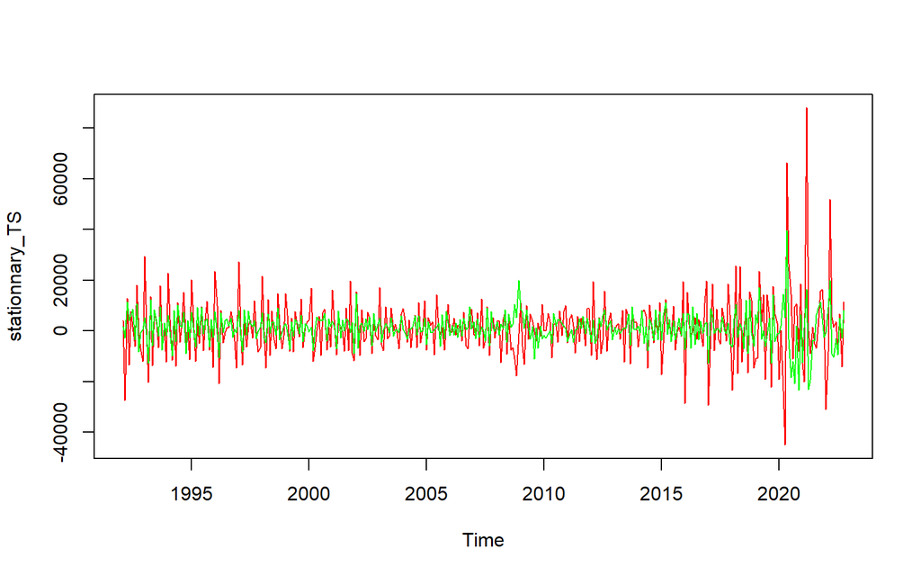

```r
auto_arma43 <- arima(stationnary_TS, order = c(4,0,4))
residus <- auto_arma43$residuals
estimated <-(stationnary_TS - residus)
plot(stationnary_TS, col = "red")
lines(estimated, col = "green")
```

On observe alors que l’approximation est plutôt bonne mais non optimale.

On considère le modèle ARIMA, extension du modèle ARMA. On a determiné que le degré d’intégration optimal est d = 1.

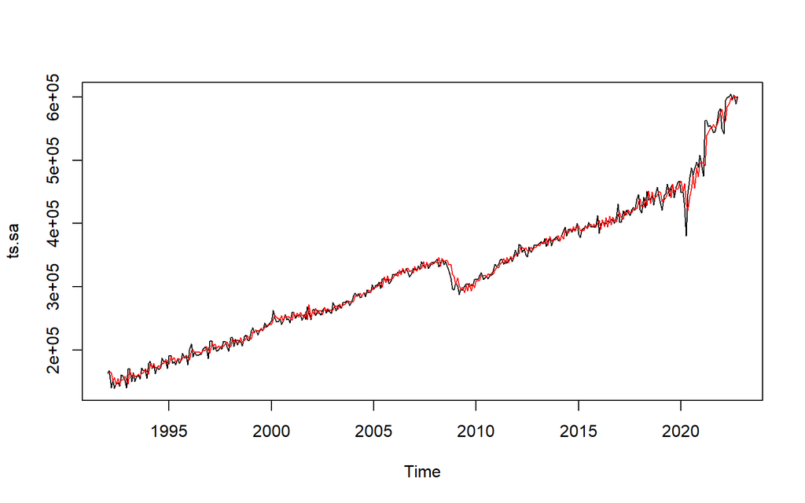

```r
auto_arma44 <- arima(ts.sa, order = c(4,1,4))
residus2 <- auto_arma44$residuals
estimated <- (ts.sa - residus)
plot(ts.sa, col = "black")
lines(estimated, col = "red")
```

### 2. Having choose the correct specification, justify the relevance of your choice with the required tests.

On effectue d’abord des tests sur les résidus :

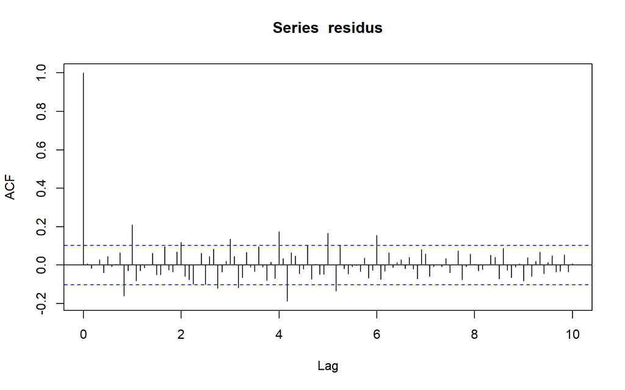

```r
acf(residus, lag = 120)
```

On observe dans un premier temps que les résidus ne sont quasiment pas autocorrélés. Ce qui confirme avec une première méthode la pertinence de nos résultats.

Test adf

```r
adf_test <- ur.df(estimated, type = "trend",7, selectlags = "AIC")
summary(adf_test)
```

```
##
## ###############################################
## # Augmented Dickey-Fuller Test Unit Root Test #
## ###############################################
##
## Test regression trend
##
##
## Call:
## lm(formula = z.diff ~ z.lag.1 + 1 + tt + z.diff.lag)
##
## Residuals:
##    Min     1Q Median     3Q    Max
## -33582  -3529   -125   3409  47161
##
## Coefficients:
##               Estimate Std. Error t value Pr(>|t|)
## (Intercept)  5.162e+02  2.657e+03   0.194  0.84606
## z.lag.1     -5.058e-04  1.841e-02  -0.027  0.97810
## tt           6.400e+00  1.739e+01   0.368  0.71317
## z.diff.lag1 -5.075e-01  5.667e-02  -8.956  < 2e-16 ***
## z.diff.lag2 -2.234e-02  6.320e-02  -0.354  0.72389
## z.diff.lag3 -9.769e-02  6.332e-02  -1.543  0.12377
## z.diff.lag4  5.419e-02  6.357e-02   0.852  0.39454
## z.diff.lag5  1.434e-01  6.272e-02   2.287  0.02280 *
## z.diff.lag6  2.429e-02  6.257e-02   0.388  0.69805
## z.diff.lag7  1.774e-01  5.429e-02   3.267  0.00119 **
## ---
## Signif. codes:  0 '***' 0.001 '**' 0.01 '*' 0.05 '.' 0.1 ' ' 1
##
## Residual standard error: 6971 on 351 degrees of freedom
## Multiple R-squared:  0.3553, Adjusted R-squared:  0.3387
## F-statistic: 21.49 on 9 and 351 DF,  p-value: < 2.2e-16
##
##
## Value of test-statistic is: -0.0275 4.5841 1.3077
##
## Critical values for test statistics:
##       1pct  5pct 10pct
## tau3 -3.98 -3.42 -3.13
## phi2  6.15  4.71  4.05
## phi3  8.34  6.30  5.36
```

```r
library("tidyquant")
jnj = tq_get("JNJ", get="stock.prices", from ="1997-01-01")%>%tq_transmute(mutate_fun=to.period, period ="months")
jnj
```

```
## # A tibble: 312 × 7
##    date        open  high   low close  volume adjusted
##    <date>     <dbl> <dbl> <dbl> <dbl>   <dbl>    <dbl>
##  1 1997-01-31  28.6  29.2  28.5  28.9 5477800     15.5
##  2 1997-02-28  28.6  29.2  28.3  28.8 4997200     15.4
##  3 1997-03-31  27.5  27.7  26.4  26.4 8000400     14.2
##  4 1997-04-30  30    30.8  30    30.6 4504600     16.4
##  5 1997-05-30  29.4  30.1  29.2  30   4558800     16.2
##  6 1997-06-30  32.4  32.4  31.6  32.2 5272000     17.3
##  7 1997-07-31  31.1  31.3  30.7  31.1 5294400     16.7
##  8 1997-08-29  28.6  28.6  28.1  28.3 4463800     15.3
##  9 1997-09-30  29.2  29.2  28.8  28.8 5560600     15.6
## 10 1997-10-31  28.7  28.9  28.1  28.7 5072800     15.5
## # … with 302 more rows
```

### 1. Determine the degree of integration of the Johnson & Johnson stock prices.

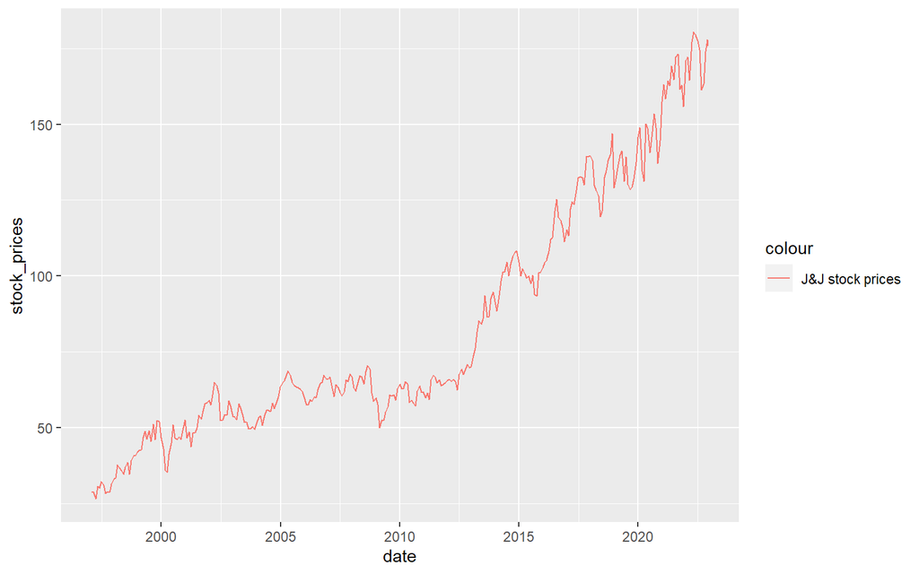

```r
library(ggplot2)
stock_prices <- ts(jnj$close, start = c(1997,1), frequency = 12)
p1 <- ggplot(jnj, aes(x = date)) + geom_line(aes(y = stock_prices, col = "J&J stock prices"))
p1
```

On conjecture graphiquement la présence d’une tendance croissante. On effectue alors des tests de racine unitaire pour determiner l’ordre d’intégration J&J. #### Test adf :

```r
summary(ur.df(diff(stock_prices)))
```

```
##
## ###############################################
## # Augmented Dickey-Fuller Test Unit Root Test #
## ###############################################
##
## Test regression none
##
##
## Call:
## lm(formula = z.diff ~ z.lag.1 - 1 + z.diff.lag)
##
## Residuals:
##      Min       1Q   Median       3Q      Max
## -16.8892  -1.4539   0.6603   2.7909  15.7410
##
## Coefficients:
##            Estimate Std. Error t value Pr(>|t|)
## z.lag.1    -1.28646    0.08188 -15.712  < 2e-16 ***
## z.diff.lag  0.20012    0.05599   3.574 0.000408 ***
## ---
## Signif. codes:  0 '***' 0.001 '**' 0.01 '*' 0.05 '.' 0.1 ' ' 1
##
## Residual standard error: 4.211 on 307 degrees of freedom
## Multiple R-squared:  0.5546, Adjusted R-squared:  0.5517
## F-statistic: 191.2 on 2 and 307 DF,  p-value: < 2.2e-16
##
##
## Value of test-statistic is: -15.7117
##
## Critical values for test statistics:
##       1pct  5pct 10pct
## tau1 -2.58 -1.95 -1.62
```

On observe que pour un ordre d’intégration d = 1, la série est stationnaire car la valeur de la statistique est inférieure à toutes les valeurs critiques de Dickey fuller.

#### Test KPSS :

```r
summary(ur.kpss(diff(stock_prices)))
```

```
##
## #######################
## # KPSS Unit Root Test #
## #######################
##
## Test is of type: mu with 5 lags.
##
## Value of test-statistic is: 0.1954
##
## Critical value for a significance level of:
##                 10pct  5pct 2.5pct  1pct
## critical values 0.347 0.463  0.574 0.739
```

On observe que pour un ordre d’intégration d = 1, la série est stationnaire car la valeur de la statistique est inférieure à toutes les valeurs critiques de KPSS.

On conclut de ces deux tests que le degré d’intégration de la data est d = 1.

### 2. Determine the order of the ARIMA model, i.e the values of p, d, q to be used to model the stock prices. Note first, the assessment of p and q cannot be performed on the data expressed in level.Note besides, the determination of the values of p and q can be performed using different methods (graphical approach vs information criteria).

```r
stationnary_prices <- diff(stock_prices)

armaloop=function(ts){
  aics=0
  k=1
  for (p in 0:4){
    for (q in 0:4){
      arma=arima(ts,order=c(p,0,q))
      aics[k]=AIC(arma)
      k=k+1
    }
  }
  names(aics)=c("(0,0)","(0,1)","(0,2)","(0,3)","(0,4)","(1,0)","(1,1)","(1,2)","(1,3)","(1,4)","(2,0)","(2,1)","(2,2)","(2,3)","(2,4)","(3,0)","(3,1)","(3,2)","(3,3)","(3,4)","(4,0)","(4,1)","(4,2)","(4,3)","(4,4)")
  return(aics)
}
armaloop(stationnary_prices)
```

```
##    (0,0)    (0,1)    (0,2)    (0,3)    (0,4)    (1,0)    (1,1)    (1,2)
## 1787.623 1785.592 1770.973 1772.596 1773.935 1787.344 1774.424 1772.325
##    (1,3)    (1,4)    (2,0)    (2,1)    (2,2)    (2,3)    (2,4)    (3,0)
## 1773.619 1773.575 1774.380 1773.406 1771.950 1773.580 1775.403 1775.146
##    (3,1)    (3,2)    (3,3)    (3,4)    (4,0)    (4,1)    (4,2)    (4,3)
## 1773.579 1773.665 1775.551 1777.376 1776.664 1775.519 1775.205 1777.171
##    (4,4)
## 1773.256
```

```r
min(armaloop(stationnary_prices))
```

```
## [1] 1770.973
```

On obtient alors que le modèle le plus pertinent est un ARMA(0,2).

### 3. Estimate the corresponding ARIMA(p,d,q) model to the values of p,d,q selected previously. Check the estimated coefficients and compute the fit of the model. Plot (within the same chart) the estimated values of the stock price and the observed one.

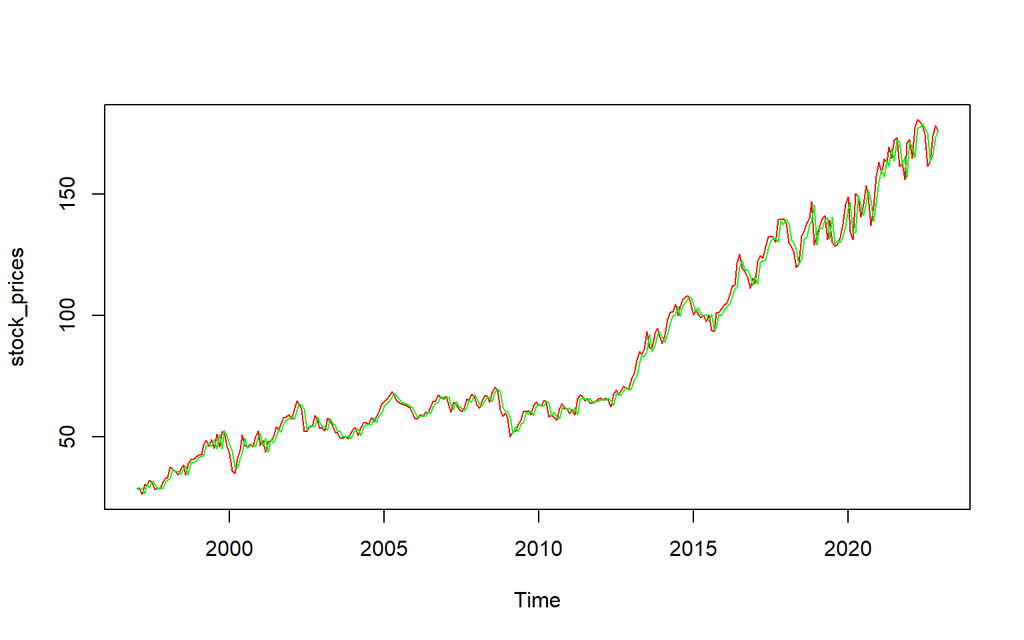

```r
auto_arma1 <- arima(stock_prices, order = c(0,1,2))
residus <- auto_arma1$residuals
estimated <-(stock_prices - residus)
plot(stock_prices, col = "red")
lines(estimated, col = "green")
```

### 4. Calculate the residual of the model, given as the difference between J&ˆ J and J&J. Compute the required quality checks on the residuals.

```r
residus <- stock_prices - estimated
RMSE <- function(observed,predicted)
{
  rmse <- sqrt(mean((observed-predicted)^2))
  rmse
}
Rmse <- RMSE(stock_prices,estimated)
Rmse
```

```
## [1] 4.172119
```

### 5. Using the estimated coefficients, generate a forecast over the next 3 months. Calculate the confidence interval of the forecasted points.

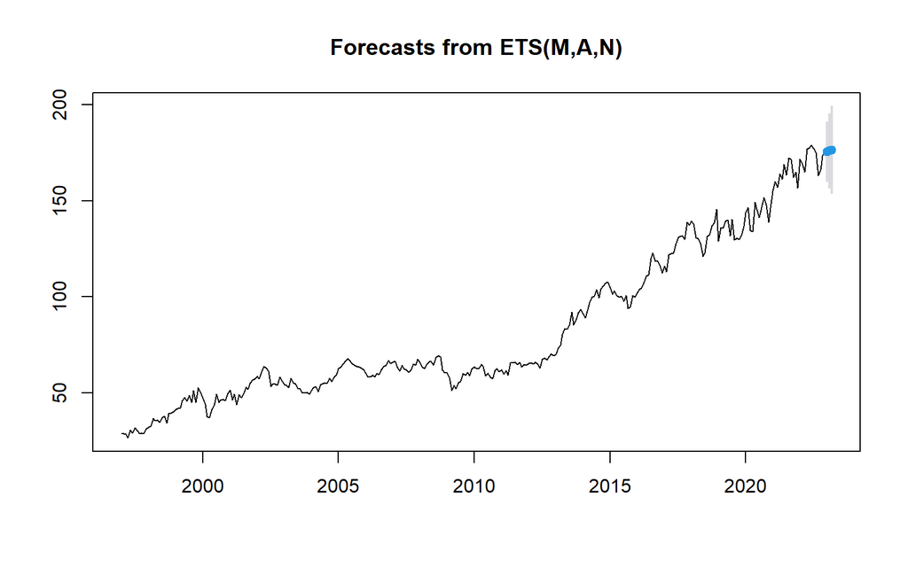

```r
fc <- forecast(estimated, level = c(95), h = 3)
plot(fc,type= "l")
```

## Exercise 5 : Unit root test another one :

### 1. Present the Zivot and Andrews (1992) test paying attention to the nature of the breaks. Explain the strategy of the test.

Ce test analyse si le modèle une racine unitaire et des breaks Hypothèse H0: la série à une racine unitaire avec break(s) Hypothèse H1: la série est stationaire avec break(s) On rejette l’hypothèse nulle si la t-statistic est < à la critical value

```r
par(mfrow = c(3,1))
#Simulation of a withe noise process
set.seed(123)
w.n = rnorm(1000,0,1.7)

#generate simple a random walk
rw = cumsum(w.n)
plot(rw,type="l", main = "Simple random walk")


shock = function(taille)
{
  norm=0
  set.seed(4)
  al=sample(1:1000,1)
  print(al)
  for(i in 2:1000){
    if(i==al){
      norm[i]=rnorm(1,0,taille)
    }
    else{
      norm[i]=norm[i-1]
    }
  }
  return(norm)
}

#génération d'un random walk avec break
rw.break.level = rw +shock(80)
```

```
## [1] 504
```

```r
plot(rw.break.level,type="l", col = "blue", main ="Random walk with break in level")

#génération d'une tendance t et d'un random walk simple avec drift et shock
t = 1:1000
rw.break.trend = rw + 0.15*t +shock(80)
```

```
## [1] 504
```

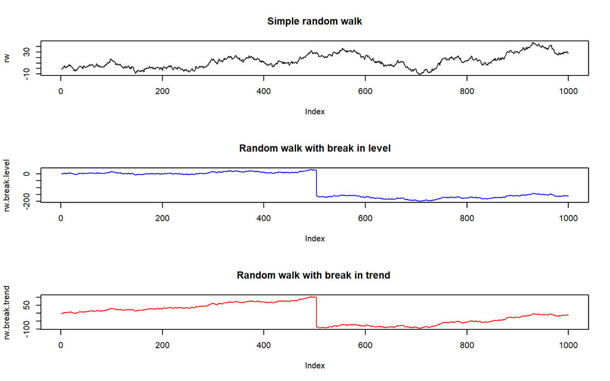

```r
plot(rw.break.trend ,type="l", col = "red", main = "Random walk with break in trend ")
```

### 3. Compute the appropriate Zivot and Andrews (1992) test for the generated random walk. Summarize your output within a table.

```r
summary(ur.za(rw))
```

```
##
## ################################
## # Zivot-Andrews Unit Root Test #
## ################################
##
##
## Call:
## lm(formula = testmat)
##
## Residuals:
##     Min      1Q  Median      3Q     Max
## -4.8147 -1.0848  0.0308  1.1156  5.2681
##
## Coefficients:
##               Estimate Std. Error t value Pr(>|t|)
## (Intercept) -0.1751200  0.1284302  -1.364 0.173020
## y.l1         0.9764725  0.0061283 159.339  < 2e-16 ***
## trend        0.0016546  0.0004856   3.407 0.000682 ***
## du          -0.7250576  0.2395525  -3.027 0.002536 **
## ---
## Signif. codes:  0 '***' 0.001 '**' 0.01 '*' 0.05 '.' 0.1 ' ' 1
##
## Residual standard error: 1.675 on 995 degrees of freedom
##   (1 observation effacée parce que manquante)
## Multiple R-squared:  0.9818, Adjusted R-squared:  0.9817
## F-statistic: 1.786e+04 on 3 and 995 DF,  p-value: < 2.2e-16
##
##
## Teststatistic: -3.8392
## Critical values: 0.01= -5.34 0.05= -4.8 0.1= -4.58
##
## Potential break point at position: 578
```

```r
summary(ur.za(rw.break.level))
```

```
##
## ################################
## # Zivot-Andrews Unit Root Test #
## ################################
##
##
## Call:
## lm(formula = testmat)
##
## Residuals:
##      Min       1Q   Median       3Q      Max
## -128.348   -1.912    0.005    2.372    9.523
##
## Coefficients:
##               Estimate Std. Error t value Pr(>|t|)
## (Intercept)  -0.536086   0.367421  -1.459    0.145
## y.l1          0.714214   0.013772  51.861   <2e-16 ***
## trend         0.011251   0.001207   9.320   <2e-16 ***
## du          -56.811119   2.732895 -20.788   <2e-16 ***
## ---
## Signif. codes:  0 '***' 0.001 '**' 0.01 '*' 0.05 '.' 0.1 ' ' 1
##
## Residual standard error: 5.164 on 995 degrees of freedom
##   (1 observation effacée parce que manquante)
## Multiple R-squared:  0.9967, Adjusted R-squared:  0.9967
## F-statistic: 1.001e+05 on 3 and 995 DF,  p-value: < 2.2e-16
##
##
## Teststatistic: -20.7516
## Critical values: 0.01= -5.34 0.05= -4.8 0.1= -4.58
##
## Potential break point at position: 503
```

```r
summary(ur.za(rw.break.trend))
```

```
##
## ################################
## # Zivot-Andrews Unit Root Test #
## ################################
##
##
## Call:
## lm(formula = testmat)
##
## Residuals:
##      Min       1Q   Median       3Q      Max
## -128.348   -1.912    0.005    2.372    9.523
##
## Coefficients:
##               Estimate Std. Error t value Pr(>|t|)
## (Intercept)  -0.428954   0.367410  -1.168    0.243
## y.l1          0.714214   0.013772  51.861   <2e-16 ***
## trend         0.054119   0.002729  19.834   <2e-16 ***
## du          -56.811119   2.732895 -20.788   <2e-16 ***
## ---
## Signif. codes:  0 '***' 0.001 '**' 0.01 '*' 0.05 '.' 0.1 ' ' 1
##
## Residual standard error: 5.164 on 995 degrees of freedom
##   (1 observation effacée parce que manquante)
## Multiple R-squared:  0.9923, Adjusted R-squared:  0.9923
## F-statistic: 4.275e+04 on 3 and 995 DF,  p-value: < 2.2e-16
##
##
## Teststatistic: -20.7516
## Critical values: 0.01= -5.34 0.05= -4.8 0.1= -4.58
##
## Potential break point at position: 503
```

### 4. Is it relevant to use such test for the filtered retail sales. Justify. Compute the Zivot and Andrews (1992) unit root test using the US retail sales.

# Exercice 6 : Modeling the business cycle

Import et conversion des données :

```r
us.gdp = read.csv("GDPC1.csv")
us.gdp$DATE <- as.Date(us.gdp$DATE, format = "%Y-%m-%d")
head(us.gdp)
```

```
##         DATE    GDPC1
## 1 1947-01-01 2034.450
## 2 1947-04-01 2029.024
## 3 1947-07-01 2024.834
## 4 1947-10-01 2056.508
## 5 1948-01-01 2087.442
## 6 1948-04-01 2121.899
```

On commence par visualiser les données pour determiner les facteurs qui empèchent la stationnarité :

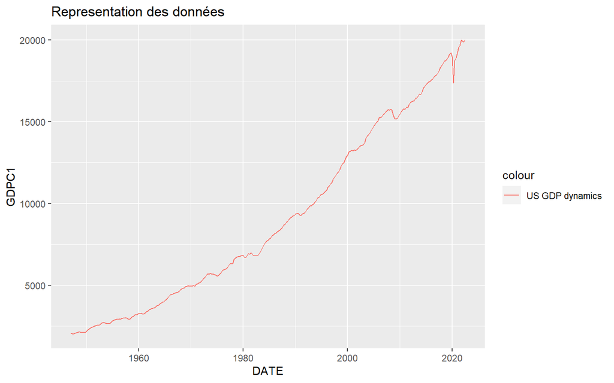

```r
dataplot <- ggplot(us.gdp, aes(x = DATE, y = GDPC1, col = "US GDP dynamics")) + geom_line() + ggtitle("Representation des données")
dataplot
```

à première vue, on observe la présence d’une trend croissante et de breaks en niveau dans la série temporelle. Ceci justifie tout d’abord graphiquement l’abscence de stationnarité.Cette fois ci, il n’y a pas de saisonnalité.

Ces conjectures se verifient par les tests statistiques :

## Generation de la série temporelle :

```r
us.gdp.ts = ts(us.gdp$GDPC1, start = c(1947,1), frequency = 4)
us.gdp.ts
```

```
##           Qtr1      Qtr2      Qtr3      Qtr4
## 1947  2034.450  2029.024  2024.834  2056.508
## 1948  2087.442  2121.899  2134.056  2136.440
## 1949  2107.001  2099.814  2121.493  2103.688
## 1950  2186.365  2253.045  2340.112  2384.920
## 1951  2417.311  2459.196  2509.880  2515.408
## 1952  2542.286  2547.762  2566.153  2650.431
## 1953  2699.699  2720.566  2705.258  2664.302
## 1954  2651.566  2654.456  2684.434  2736.960
## 1955  2815.134  2860.942  2899.578  2916.985
## 1956  2905.656  2929.666  2927.034  2975.209
## 1957  2994.259  2987.699  3016.979  2985.775
## 1958  2908.281  2927.395  2995.112  3065.141
## 1959  3123.978  3194.429  3196.683  3205.790
## 1960  3277.847  3260.177  3276.133  3234.087
```

[output cut: 62 more lines]

## Acf :

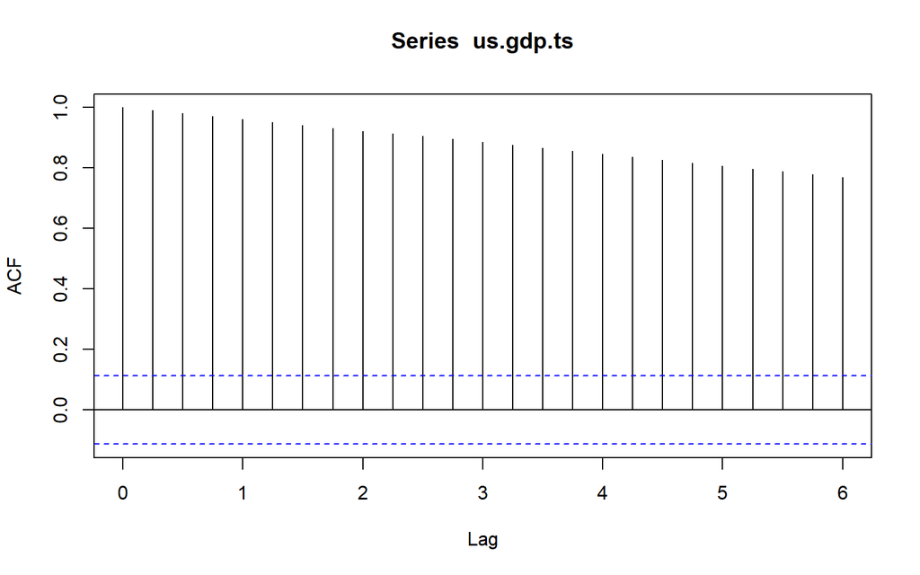

```r
acf(us.gdp.ts)
```

On observe une très forte autocorrélation.

On poursuit en considérant des tests pour justifier l’impact de la trend sur l’abscence de stationnarité :

## test Kpss :

On commence par appliquer un test de kpss sur la série non différenciée :

```r
kpss <- ur.kpss(us.gdp.ts, lags = "short")
summary(kpss)
```

```
##
## #######################
## # KPSS Unit Root Test #
## #######################
##
## Test is of type: mu with 5 lags.
##
## Value of test-statistic is: 5.0458
##
## Critical value for a significance level of:
##                 10pct  5pct 2.5pct  1pct
## critical values 0.347 0.463  0.574 0.739
```

On constate que la statistique du test est égale à 5.0458 et est supérieure aux valeurs critiques. De ce fait, on rejette l’hypothèse H0 de stationnarité du test KPSS

On applique alors une nouvelle fois le test sur la série différenciée :

```r
diff <- diff(us.gdp.ts)
kpss_diff <- ur.kpss(diff, lags = "short")
summary(kpss_diff)
```

```
##
## #######################
## # KPSS Unit Root Test #
## #######################
##
## Test is of type: mu with 5 lags.
##
## Value of test-statistic is: 0.9826
##
## Critical value for a significance level of:
##                 10pct  5pct 2.5pct  1pct
## critical values 0.347 0.463  0.574 0.739
```

À ce stade, avant d’intégrer une nouvelle fois, on peut visualiser les données pour tenter de faire une conjecture.

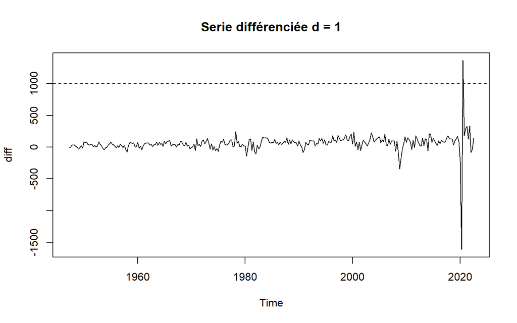

```r
plot(diff, main = "Serie différenciée d = 1")
abline(h=1000, col="blue",lty = 2)
```

En visualisant les données, constate qu’à priori l’allure de la série temporelle différenciée est stationnaire. Le seul problème survient en 2020, et représente le desordre engendré par la crise covid. On peut supposer d’après cette conjecture que le degré d’intégration necessaire à retirer la trend est d = 1. L’écart entre la statistique du test kpss sur la série différenciée et les valeurs critiques est alors potentiellement engendré par le break dû au COVID.

On applique une nouvelle differenciation et on génère test kpss et visualisation pour vérifier la cohérence du propos :

```r
summary(ur.kpss(diff(diff), lags = "short"))
```

```
##
## #######################
## # KPSS Unit Root Test #
## #######################
##
## Test is of type: mu with 5 lags.
##
## Value of test-statistic is: 0.0094
##
## Critical value for a significance level of:
##                 10pct  5pct 2.5pct  1pct
## critical values 0.347 0.463  0.574 0.739
```

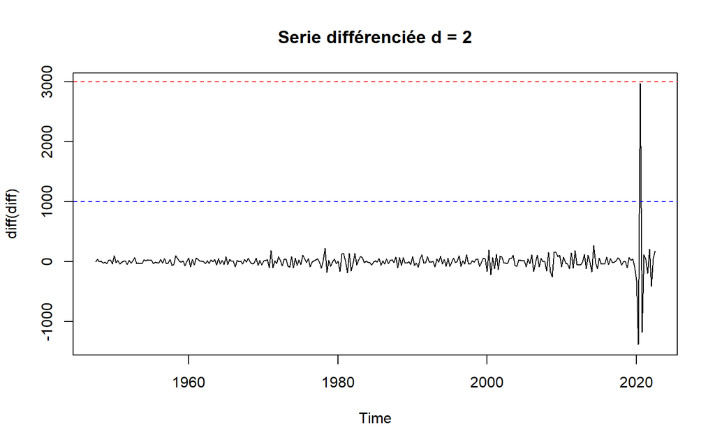

```r
plot(diff(diff), main = "Serie différenciée d = 2")
abline(h=1000, col="blue",lty = 2)
abline(h=3000, col="red", lty = 2)
```

Comme prévu on obsère qu’après une seconde différenciation, la valeur de la statistique est largement inférieure aux valeurs critiques. Peut-on alors déduire que le degré d’intégration est de 2 ?

À mon sens, non. La visualisation graphique et le test kpss confirment selon moi mon hypothèse précédente. l’allure de la nouvelle série d’ordre de différenciation 2 est toujours stationnaire, mais le seul impact qu’a eu la différenciation est de réduire l’amplitude globale. En revanche, le break autour de 2020 a lui été accentué.

On conserve alors un ordre de différenciation de d = 1.

Pour confirmer notre conjécture on génère un test Zivot & Andrews sur nos données :

## Zivot & Andrews :

```r
us.gdp.za = ur.za(us.gdp.ts)
summary(us.gdp.za)
```

```
##
## ################################
## # Zivot-Andrews Unit Root Test #
## ################################
##
##
## Call:
## lm(formula = testmat)
##
## Residuals:
##      Min       1Q   Median       3Q      Max
## -1648.10   -30.29     8.13    45.16  1032.10
##
## Coefficients:
##              Estimate Std. Error t value Pr(>|t|)
## (Intercept) 2.914e+01  1.603e+01   1.818  0.07010 .
## y.l1        9.769e-01  8.106e-03 120.523  < 2e-16 ***
## trend       1.518e+00  4.959e-01   3.061  0.00241 **
## du          2.573e+02  4.948e+01   5.199 3.73e-07 ***
## ---
## Signif. codes:  0 '***' 0.001 '**' 0.01 '*' 0.05 '.' 0.1 ' ' 1
##
## Residual standard error: 135.7 on 298 degrees of freedom
##   (1 observation effacée parce que manquante)
## Multiple R-squared:  0.9994, Adjusted R-squared:  0.9994
## F-statistic: 1.608e+05 on 3 and 298 DF,  p-value: < 2.2e-16
##
##
## Teststatistic: -2.8487
## Critical values: 0.01= -5.34 0.05= -4.8 0.1= -4.58
##
## Potential break point at position: 294
```

Le test statistique indique la présence potentielle d’un break à la 294ème position. La valeur de la statistique du test est supérieure à la valeur critique à 1%. On ne peut donc pas rejetter l’hypothèse de présence de racine unitaire. Cela confirme donc l’abscence de stationnarité dans la série initiale.

```r
us.gdp[294,]
```

```
##           DATE    GDPC1
## 294 2020-04-01 17378.71
```

cette position fait référence à la date du 1er avril 2020. Ce qui correspond bel et bien à la période covid.

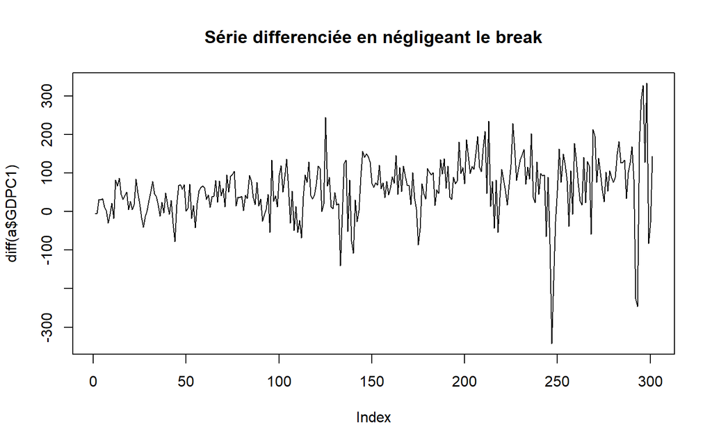

```r
a <- us.gdp[-294,]
plot(diff(a$GDPC1), type = "l", main ="Série differenciée en négligeant le break")
```

On observe que l’allure de la série différenciée en écartant le point de rupture est stationnaire et d’amplitude beaucoup plus régulière.

Vérification : —————

```r
us.gdp.nobreak = ur.za(diff(a$GDPC1))
summary(us.gdp.nobreak)
```

```
##
## ################################
## # Zivot-Andrews Unit Root Test #
## ################################
##
##
## Call:
## lm(formula = testmat)
##
## Residuals:
##     Min      1Q  Median      3Q     Max
## -360.05  -31.96    5.39   35.67  234.38
##
## Coefficients:
##              Estimate Std. Error t value Pr(>|t|)
## (Intercept)   4.44627    9.04508   0.492   0.6234
## y.l1          0.31899    0.05495   5.805 1.65e-08 ***
## trend         0.28683    0.06935   4.136 4.61e-05 ***
## du          -31.65033   14.00770  -2.259   0.0246 *
## ---
## Signif. codes:  0 '***' 0.001 '**' 0.01 '*' 0.05 '.' 0.1 ' ' 1
##
## Residual standard error: 69.13 on 296 degrees of freedom
##   (1 observation effacée parce que manquante)
## Multiple R-squared:  0.2056, Adjusted R-squared:  0.1976
## F-statistic: 25.54 on 3 and 296 DF,  p-value: 1.013e-14
##
##
## Teststatistic: -12.3939
## Critical values: 0.01= -5.34 0.05= -4.8 0.1= -4.58
##
## Potential break point at position: 236
```

On applique une nouvelle fois le test de zivot & andrews sur la série différenciée en négligeant le point de break et on constate qe la valeur du test statistique est inférieure aux valeurs critiques. On peut alors rejetter l’hypothèse de présence de racine unitaire. La série différenciée de la sorte est alors stationnaire.

Pour la suite de l’étude on comparera quand même entre les deux degrés d’intégration d1 = 1 et d2 = 2.

## Generation d’un modèle pertinent pour approcher les données :

```r
for (i in 0:3)
{
  for (j in 0:3)
  {
    aic = Arima(diff(us.gdp.ts) , c(i,0,j))$aic
    bic = Arima(diff(us.gdp.ts) , c(i,0,j))$bic

    print(paste0("AIC for ARMA(", i, ",", j, ") = ", aic))
    print(paste0("BIC for ARMA(", i, ",", j, ") = ", bic))
    print("------------------------------------------------")
  }
}
```

```
## [1] "AIC for ARMA(0,0) = 3859.16859579012"
## [1] "BIC for ARMA(0,0) = 3866.58944982487"
## [1] "------------------------------------------------"
## [1] "AIC for ARMA(0,1) = 3855.08276772268"
## [1] "BIC for ARMA(0,1) = 3866.2140487748"
## [1] "------------------------------------------------"
## [1] "AIC for ARMA(0,2) = 3856.77325172217"
## [1] "BIC for ARMA(0,2) = 3871.61495979167"
## [1] "------------------------------------------------"
## [1] "AIC for ARMA(0,3) = 3858.76801934919"
## [1] "BIC for ARMA(0,3) = 3877.32015443606"
## [1] "------------------------------------------------"
## [1] "AIC for ARMA(1,0) = 3854.83845644566"
## [1] "BIC for ARMA(1,0) = 3865.96973749778"
## [1] "------------------------------------------------"
```

[output cut: 33 more lines]

On trouve que le modèle est optimal pour p = 1 et q = 0.

On génère un modèle ARMA adapté aux paramètres obtenus :

```r
arima_d1 <- arima(us.gdp.ts, order = c(1,1,0))
arima_d2 <- arima(us.gdp.ts, order = c(1,2,0))
```

On génère le plot pour observer l’approche des données :

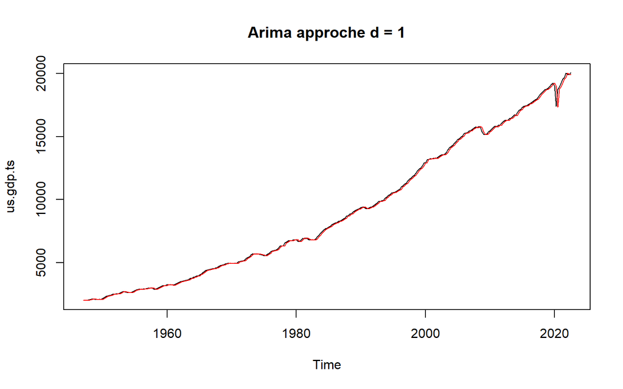

```r
# Génération des résdus :
residus1 <- arima_d1$residuals
residus2 <- arima_d2$residuals

# Estimations :
estimated1 <- (us.gdp.ts - residus1)
estimated2 <- (us.gdp.ts - residus2)

# Plot

plot(us.gdp.ts, col = "black", main = "Arima approche d = 1")
lines(estimated1, col = "red")
```

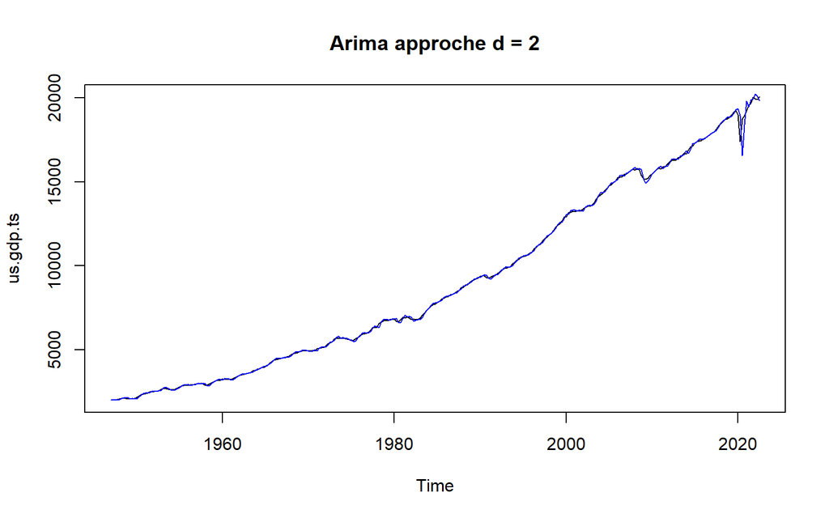

```r
plot(us.gdp.ts, col = "black", main = "Arima approche d = 2")
lines(estimated2, col = "blue")
```

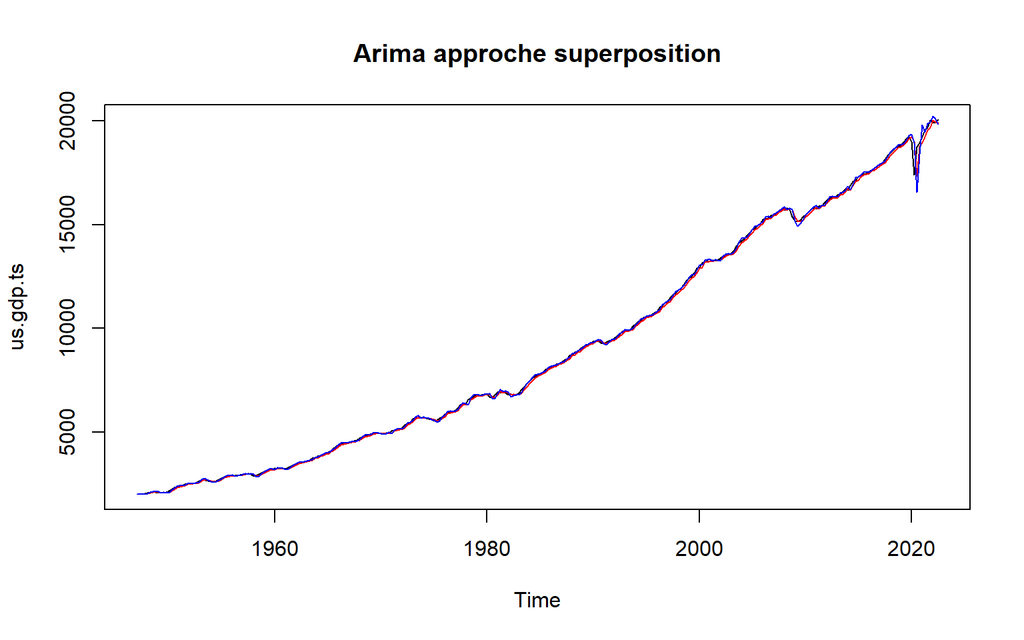

```r
plot(us.gdp.ts, col = "black", main = "Arima approche superposition")
lines(estimated1, col = "red")
lines(estimated2, col = "blue")
```

On constate que l’estimation semble pertinente dans les deux cas. Néanmoins, l’approche par un ordre d’intégration 1 fit mieux la série temporelle. De ce fait, on confirme les hypothèses faites précédemment.

On génère alors les prédictions sur les données :

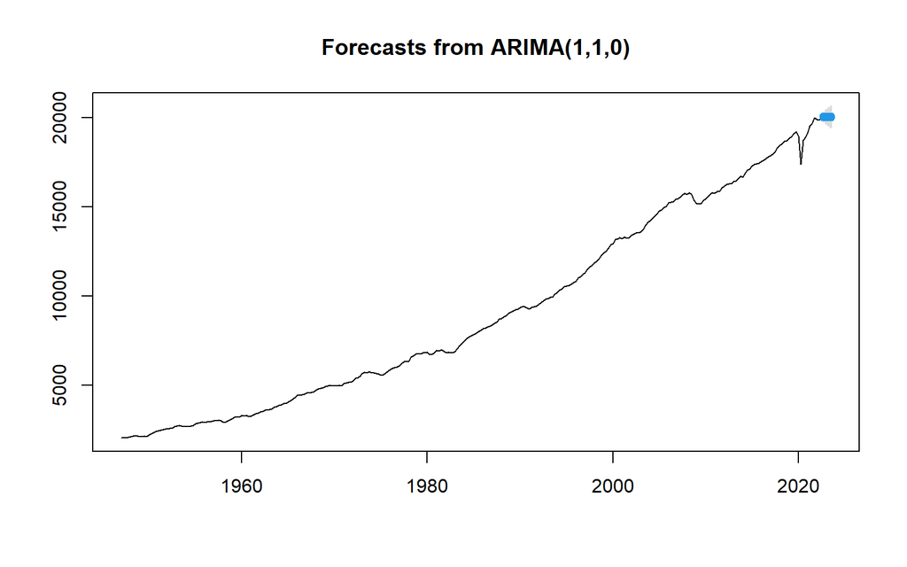

```r
forecasted1 = forecast(arima_d1, level = c(95), h=4)
plot(forecasted1)
```

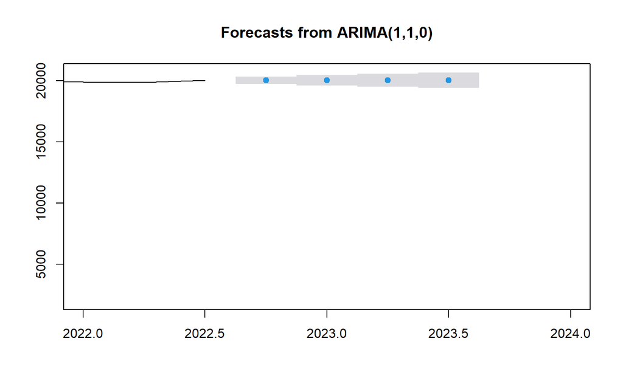

```r
plot(forecasted1, xlim = c(2022,2024))
```

```r
forecasted1
```

```
##         Point Forecast    Lo 95    Hi 95
## 2022 Q4       20042.92 19739.11 20346.73
## 2023 Q1       20043.00 19608.08 20477.92
## 2023 Q2       20043.01 19508.10 20577.91
## 2023 Q3       20043.01 19424.06 20661.95
```

Conformément à la représenation graphique, et aux valeurs assiociées, la prediction semble pertinente par rapport aux données connues sur la série temporelle. Graphiquement, les points s’inscrivent dans une continuité logique par rapport à la visualisation.

On effectue la même prédiction avec les données intégrées à l’ordre 2 :

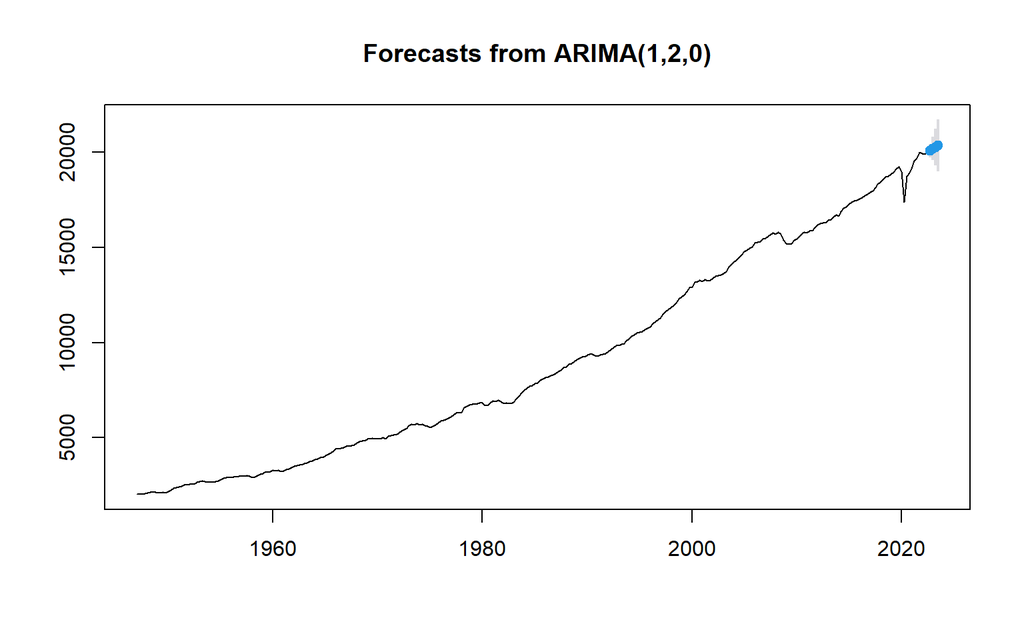

```r
forecasted2 = forecast(arima_d2, level = c(95), h=4)
plot(forecasted2)
```

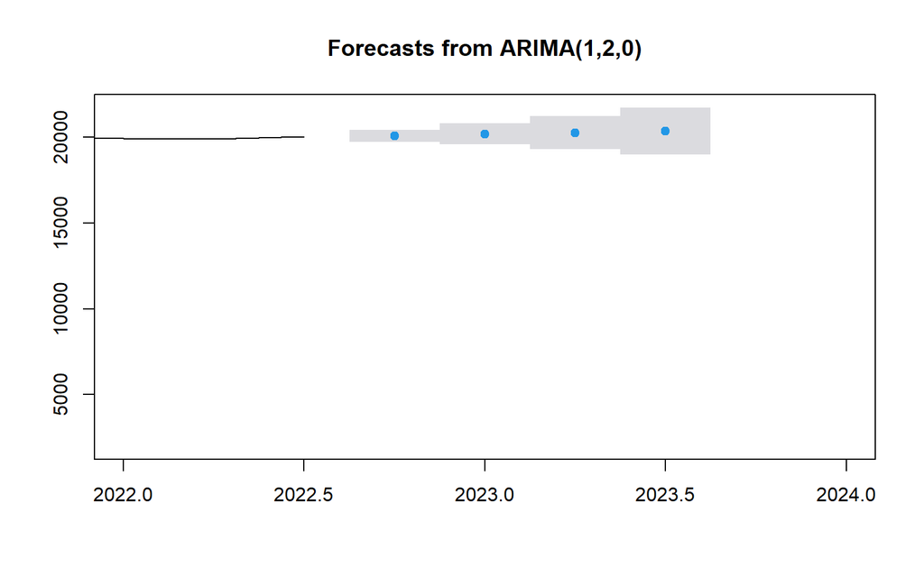

```r
plot(forecasted2, xlim = c(2022,2024))
```

```r
forecasted2
```

```
##         Point Forecast    Lo 95    Hi 95
## 2022 Q4       20084.23 19736.74 20431.72
## 2023 Q1       20186.08 19580.92 20791.24
## 2023 Q2       20255.19 19285.26 21225.11
## 2023 Q3       20343.09 18982.12 21704.07
```

On constate que les deux modèles sont pertinents. Pour d = 1, les predictions semblent proches les unes des autres alors que pour d = 2. on constate plus de fluctuation.